# Project: No-Show Appointments Data Analysis

- Introduction
- Data Wrangling
- Exploratory Data Analysis
- Conclusions

## Introduction

> In This Project We will be analyzing data regarding 100K medical appointments varying between show and no show in brazil to realize what trends and factors affect their ability to show up So our main question will be What factors are important for us to know in order to predict if a patient will show up for their scheduled appointment?

```python
! pip install pandas==0.25
```

[output not shown]

```python
# in this cell we include all of our imports (numpy,pandas,matblotlib,seaborn)
import numpy as np
import pandas as pd
import matplotlib.pyplot as plt
import seaborn as sns
from pandas_profiling import ProfileReport
%matplotlib inline
```

## Data Wrangling

### General Properties

```python
# Read CSV Data
df = pd.read_csv('noshowappointments-kagglev2-may-2016.csv')
# Show Data Head
df.head()
```

|  | PatientId | AppointmentID | Gender | ScheduledDay | AppointmentDay | Age | Neighbourhood | Scholarship | Hipertension | Diabetes | Alcoholism | Handcap | SMS_received | No-show |
| --- | --- | --- | --- | --- | --- | --- | --- | --- | --- | --- | --- | --- | --- | --- |
| 0 | 2.987250e+13 | 5642903 | F | 2016-04-29T18:38:08Z | 2016-04-29T00:00:00Z | 62 | JARDIM DA PENHA | 0 | 1 | 0 | 0 | 0 | 0 | No |
| 1 | 5.589978e+14 | 5642503 | M | 2016-04-29T16:08:27Z | 2016-04-29T00:00:00Z | 56 | JARDIM DA PENHA | 0 | 0 | 0 | 0 | 0 | 0 | No |
| 2 | 4.262962e+12 | 5642549 | F | 2016-04-29T16:19:04Z | 2016-04-29T00:00:00Z | 62 | MATA DA PRAIA | 0 | 0 | 0 | 0 | 0 | 0 | No |
| 3 | 8.679512e+11 | 5642828 | F | 2016-04-29T17:29:31Z | 2016-04-29T00:00:00Z | 8 | PONTAL DE CAMBURI | 0 | 0 | 0 | 0 | 0 | 0 | No |
| 4 | 8.841186e+12 | 5642494 | F | 2016-04-29T16:07:23Z | 2016-04-29T00:00:00Z | 56 | JARDIM DA PENHA | 0 | 1 | 1 | 0 | 0 | 0 | No |

Overview

Dataset info

| Number of variables | 14 |
| --- | --- |
| Number of observations | 110527 |
| Total Missing (%) | 0.0% |
| Total size in memory | 11.8 MiB |
| Average record size in memory | 112.0 B |

Variables types

| Numeric | 4 |
| --- | --- |
| Categorical | 5 |
| Boolean | 5 |
| Date | 0 |
| Text (Unique) | 0 |
| Rejected | 0 |
| Unsupported | 0 |

Warnings

- `ScheduledDay` has a high cardinality: 103549 distinct values Warning

- `Age` has 3539 / 3.2% zeros Zeros

- `Neighbourhood` has a high cardinality: 81 distinct values Warning

- `Handcap` has 108286 / 98.0% zeros Zeros

Variables

PatientId  
Numeric

| Distinct count | 62299 |
| --- | --- |
| Unique (%) | 56.4% |
| Missing (%) | 0.0% |
| Missing (n) | 0 |
| Infinite (%) | 0.0% |
| Infinite (n) | 0 |

| Mean | 147500000000000 |
| --- | --- |
| Minimum | 39218 |
| Maximum | 999980000000000 |
| Zeros (%) | 0.0% |

Toggle details

**Statistics**

Quantile statistics

| Minimum | 39218 |
| --- | --- |
| 5-th percentile | 137030000000 |
| Q1 | 4172600000000 |
| Median | 31732000000000 |
| Q3 | 94392000000000 |
| 95-th percentile | 818550000000000 |
| Maximum | 999980000000000 |
| Range | 999980000000000 |
| Interquartile range | 90219000000000 |

Descriptive statistics

| Standard deviation | 256090000000000 |
| --- | --- |
| Coef of variation | 1.7363 |
| Kurtosis | 2.5829 |
| Mean | 147500000000000 |
| MAD | 186340000000000 |
| Skewness | 1.9677 |
| Sum | 1.6302e+19 |
| Variance | 6.5585e+28 |
| Memory size | 863.6 KiB |

**Histogram**

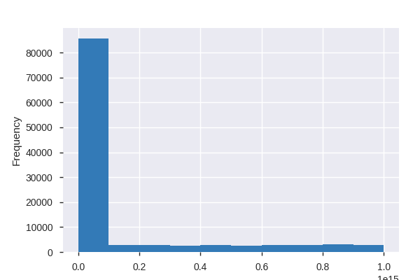

**Common Values**

| Value | Count | Frequency (%) |  |
| --- | --- | --- | --- |
| 822145925426128.0 | 88 | 0.1% |  |
| 99637671331.0 | 84 | 0.1% |  |
| 26886125921145.0 | 70 | 0.1% |  |
| 33534783483176.0 | 65 | 0.1% |  |
| 258424392677.0 | 62 | 0.1% |  |
| 75797461494159.0 | 62 | 0.1% |  |
| 871374938638855.0 | 62 | 0.1% |  |
| 6264198675331.0 | 62 | 0.1% |  |
| 66844879846766.0 | 57 | 0.1% |  |
| 872278549442.0 | 55 | 0.0% |  |
| Other values (62289) | 109860 | 99.4% |  |

**Extreme Values**

Minimum 5 values

| Value | Count | Frequency (%) |  |
| --- | --- | --- | --- |
| 39217.84439 | 1 | 0.0% |  |
| 43741.756519999995 | 1 | 0.0% |  |
| 93779.52927 | 1 | 0.0% |  |
| 141724.16655 | 1 | 0.0% |  |
| 537615.2847600001 | 1 | 0.0% |  |

Maximum 5 values

| Value | Count | Frequency (%) |  |
| --- | --- | --- | --- |
| 999931985292928.0 | 5 | 0.0% |  |
| 999934989273974.0 | 1 | 0.0% |  |
| 999946536742891.0 | 1 | 0.0% |  |
| 999968578354866.0 | 1 | 0.0% |  |
| 999981631772427.0 | 1 | 0.0% |  |

AppointmentID  
Numeric

| Distinct count | 110527 |
| --- | --- |
| Unique (%) | 100.0% |
| Missing (%) | 0.0% |
| Missing (n) | 0 |
| Infinite (%) | 0.0% |
| Infinite (n) | 0 |

| Mean | 5675300 |
| --- | --- |
| Minimum | 5030230 |
| Maximum | 5790484 |
| Zeros (%) | 0.0% |

Toggle details

**Statistics**

Quantile statistics

| Minimum | 5030230 |
| --- | --- |
| 5-th percentile | 5548200 |
| Q1 | 5640300 |
| Median | 5680600 |
| Q3 | 5725500 |
| 95-th percentile | 5773500 |
| Maximum | 5790484 |
| Range | 760254 |
| Interquartile range | 85238 |

Descriptive statistics

| Standard deviation | 71296 |
| --- | --- |
| Coef of variation | 0.012562 |
| Kurtosis | 3.7438 |
| Mean | 5675300 |
| MAD | 53569 |
| Skewness | -1.2356 |
| Sum | 627274449377 |
| Variance | 5083100000 |
| Memory size | 863.6 KiB |

**Histogram**

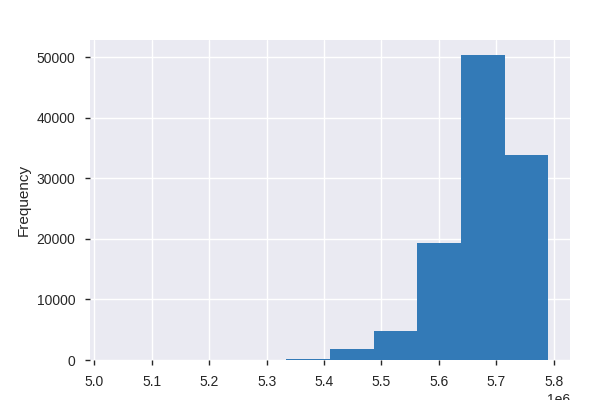

**Common Values**

| Value | Count | Frequency (%) |  |
| --- | --- | --- | --- |
| 5769215 | 1 | 0.0% |  |
| 5731652 | 1 | 0.0% |  |
| 5707080 | 1 | 0.0% |  |
| 5702986 | 1 | 0.0% |  |
| 5715276 | 1 | 0.0% |  |
| 5717325 | 1 | 0.0% |  |
| 5711182 | 1 | 0.0% |  |
| 5758289 | 1 | 0.0% |  |
| 5762391 | 1 | 0.0% |  |
| 5741913 | 1 | 0.0% |  |
| Other values (110517) | 110517 | 100.0% |  |

**Extreme Values**

Minimum 5 values

| Value | Count | Frequency (%) |  |
| --- | --- | --- | --- |
| 5030230 | 1 | 0.0% |  |
| 5122866 | 1 | 0.0% |  |
| 5134197 | 1 | 0.0% |  |
| 5134220 | 1 | 0.0% |  |
| 5134223 | 1 | 0.0% |  |

Maximum 5 values

| Value | Count | Frequency (%) |  |
| --- | --- | --- | --- |
| 5790461 | 1 | 0.0% |  |
| 5790464 | 1 | 0.0% |  |
| 5790466 | 1 | 0.0% |  |
| 5790481 | 1 | 0.0% |  |
| 5790484 | 1 | 0.0% |  |

Gender  
Categorical

| Distinct count | 2 |
| --- | --- |
| Unique (%) | 0.0% |
| Missing (%) | 0.0% |
| Missing (n) | 0 |

| F | 71840 |
| --- | --- |
| M | 38687 |

Toggle details

| Value | Count | Frequency (%) |  |
| --- | --- | --- | --- |
| F | 71840 | 65.0% |  |
| M | 38687 | 35.0% |  |

ScheduledDay  
Categorical

| Distinct count | 103549 |
| --- | --- |
| Unique (%) | 93.7% |
| Missing (%) | 0.0% |
| Missing (n) | 0 |

| 2016-05-06T07:09:54Z | 24 |
| --- | --- |
| 2016-05-06T07:09:53Z | 23 |
| 2016-04-25T17:18:27Z | 22 |
| Other values (103546) | 110458 |

Toggle details

| Value | Count | Frequency (%) |  |
| --- | --- | --- | --- |
| 2016-05-06T07:09:54Z | 24 | 0.0% |  |
| 2016-05-06T07:09:53Z | 23 | 0.0% |  |
| 2016-04-25T17:18:27Z | 22 | 0.0% |  |
| 2016-04-25T17:17:46Z | 22 | 0.0% |  |
| 2016-04-25T17:17:23Z | 19 | 0.0% |  |
| 2016-05-10T08:18:24Z | 15 | 0.0% |  |
| 2016-04-25T17:19:03Z | 15 | 0.0% |  |
| 2016-05-31T09:54:52Z | 15 | 0.0% |  |
| 2016-05-03T07:52:31Z | 14 | 0.0% |  |
| 2016-06-07T16:15:14Z | 14 | 0.0% |  |
| Other values (103539) | 110344 | 99.8% |  |

AppointmentDay  
Categorical

| Distinct count | 27 |
| --- | --- |
| Unique (%) | 0.0% |
| Missing (%) | 0.0% |
| Missing (n) | 0 |

| 2016-06-06T00:00:00Z | 4692 |
| --- | --- |
| 2016-05-16T00:00:00Z | 4613 |
| 2016-05-09T00:00:00Z | 4520 |
| Other values (24) | 96702 |

Toggle details

| Value | Count | Frequency (%) |  |
| --- | --- | --- | --- |
| 2016-06-06T00:00:00Z | 4692 | 4.2% |  |
| 2016-05-16T00:00:00Z | 4613 | 4.2% |  |
| 2016-05-09T00:00:00Z | 4520 | 4.1% |  |
| 2016-05-30T00:00:00Z | 4514 | 4.1% |  |
| 2016-06-08T00:00:00Z | 4479 | 4.1% |  |
| 2016-05-11T00:00:00Z | 4474 | 4.0% |  |
| 2016-06-01T00:00:00Z | 4464 | 4.0% |  |
| 2016-06-07T00:00:00Z | 4416 | 4.0% |  |
| 2016-05-12T00:00:00Z | 4394 | 4.0% |  |
| 2016-05-02T00:00:00Z | 4376 | 4.0% |  |
| Other values (17) | 65585 | 59.3% |  |

Age  
Numeric

| Distinct count | 104 |
| --- | --- |
| Unique (%) | 0.1% |
| Missing (%) | 0.0% |
| Missing (n) | 0 |
| Infinite (%) | 0.0% |
| Infinite (n) | 0 |

| Mean | 37.089 |
| --- | --- |
| Minimum | -1 |
| Maximum | 115 |
| Zeros (%) | 3.2% |

Toggle details

**Statistics**

Quantile statistics

| Minimum | -1 |
| --- | --- |
| 5-th percentile | 1 |
| Q1 | 18 |
| Median | 37 |
| Q3 | 55 |
| 95-th percentile | 75 |
| Maximum | 115 |
| Range | 116 |
| Interquartile range | 37 |

Descriptive statistics

| Standard deviation | 23.11 |
| --- | --- |
| Coef of variation | 0.6231 |
| Kurtosis | -0.95227 |
| Mean | 37.089 |
| MAD | 19.662 |
| Skewness | 0.12166 |
| Sum | 4099322 |
| Variance | 534.08 |
| Memory size | 863.6 KiB |

**Histogram**

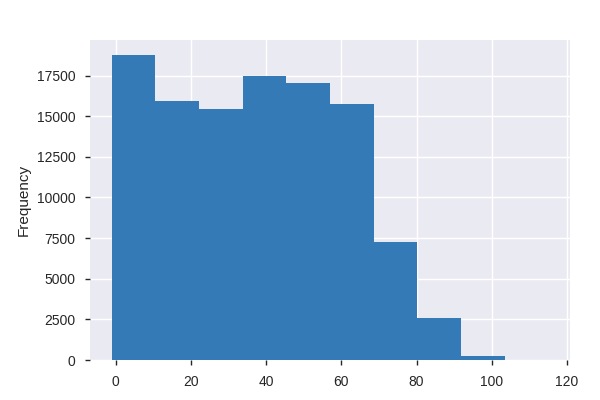

**Common Values**

| Value | Count | Frequency (%) |  |
| --- | --- | --- | --- |
| 0 | 3539 | 3.2% |  |
| 1 | 2273 | 2.1% |  |
| 52 | 1746 | 1.6% |  |
| 49 | 1652 | 1.5% |  |
| 53 | 1651 | 1.5% |  |
| 56 | 1635 | 1.5% |  |
| 38 | 1629 | 1.5% |  |
| 59 | 1624 | 1.5% |  |
| 2 | 1618 | 1.5% |  |
| 50 | 1613 | 1.5% |  |
| Other values (94) | 91547 | 82.8% |  |

**Extreme Values**

Minimum 5 values

| Value | Count | Frequency (%) |  |
| --- | --- | --- | --- |
| -1 | 1 | 0.0% |  |
| 0 | 3539 | 3.2% |  |
| 1 | 2273 | 2.1% |  |
| 2 | 1618 | 1.5% |  |
| 3 | 1513 | 1.4% |  |

Maximum 5 values

| Value | Count | Frequency (%) |  |
| --- | --- | --- | --- |
| 98 | 6 | 0.0% |  |
| 99 | 1 | 0.0% |  |
| 100 | 4 | 0.0% |  |
| 102 | 2 | 0.0% |  |
| 115 | 5 | 0.0% |  |

Neighbourhood  
Categorical

| Distinct count | 81 |
| --- | --- |
| Unique (%) | 0.1% |
| Missing (%) | 0.0% |
| Missing (n) | 0 |

| JARDIM CAMBURI | 7717 |
| --- | --- |
| MARIA ORTIZ | 5805 |
| RESISTÊNCIA | 4431 |
| Other values (78) | 92574 |

Toggle details

| Value | Count | Frequency (%) |  |
| --- | --- | --- | --- |
| JARDIM CAMBURI | 7717 | 7.0% |  |
| MARIA ORTIZ | 5805 | 5.3% |  |
| RESISTÊNCIA | 4431 | 4.0% |  |
| JARDIM DA PENHA | 3877 | 3.5% |  |
| ITARARÉ | 3514 | 3.2% |  |
| CENTRO | 3334 | 3.0% |  |
| TABUAZEIRO | 3132 | 2.8% |  |
| SANTA MARTHA | 3131 | 2.8% |  |
| JESUS DE NAZARETH | 2853 | 2.6% |  |
| BONFIM | 2773 | 2.5% |  |
| Other values (71) | 69960 | 63.3% |  |

Scholarship  
Boolean

| Distinct count | 2 |
| --- | --- |
| Unique (%) | 0.0% |
| Missing (%) | 0.0% |
| Missing (n) | 0 |

| Mean | 0.098266 |
| --- | --- |

| 0 | 99666 |
| --- | --- |
| 1 | 10861 |

Toggle details

| Value | Count | Frequency (%) |  |
| --- | --- | --- | --- |
| 0 | 99666 | 90.2% |  |
| 1 | 10861 | 9.8% |  |

Hipertension  
Boolean

| Distinct count | 2 |
| --- | --- |
| Unique (%) | 0.0% |
| Missing (%) | 0.0% |
| Missing (n) | 0 |

| Mean | 0.19725 |
| --- | --- |

| 0 | 88726 |
| --- | --- |
| 1 | 21801 |

Toggle details

| Value | Count | Frequency (%) |  |
| --- | --- | --- | --- |
| 0 | 88726 | 80.3% |  |
| 1 | 21801 | 19.7% |  |

Diabetes  
Boolean

| Distinct count | 2 |
| --- | --- |
| Unique (%) | 0.0% |
| Missing (%) | 0.0% |
| Missing (n) | 0 |

| Mean | 0.071865 |
| --- | --- |

| 0 | 102584 |
| --- | --- |
| 1 | 7943 |

Toggle details

| Value | Count | Frequency (%) |  |
| --- | --- | --- | --- |
| 0 | 102584 | 92.8% |  |
| 1 | 7943 | 7.2% |  |

Alcoholism  
Boolean

| Distinct count | 2 |
| --- | --- |
| Unique (%) | 0.0% |
| Missing (%) | 0.0% |
| Missing (n) | 0 |

| Mean | 0.0304 |
| --- | --- |

| 0 | 107167 |
| --- | --- |
| 1 | 3360 |

Toggle details

| Value | Count | Frequency (%) |  |
| --- | --- | --- | --- |
| 0 | 107167 | 97.0% |  |
| 1 | 3360 | 3.0% |  |

Handcap  
Numeric

| Distinct count | 5 |
| --- | --- |
| Unique (%) | 0.0% |
| Missing (%) | 0.0% |
| Missing (n) | 0 |
| Infinite (%) | 0.0% |
| Infinite (n) | 0 |

| Mean | 0.022248 |
| --- | --- |
| Minimum | 0 |
| Maximum | 4 |
| Zeros (%) | 98.0% |

Toggle details

**Statistics**

Quantile statistics

| Minimum | 0 |
| --- | --- |
| 5-th percentile | 0 |
| Q1 | 0 |
| Median | 0 |
| Q3 | 0 |
| 95-th percentile | 0 |
| Maximum | 4 |
| Range | 4 |
| Interquartile range | 0 |

Descriptive statistics

| Standard deviation | 0.16154 |
| --- | --- |
| Coef of variation | 7.261 |
| Kurtosis | 82.556 |
| Mean | 0.022248 |
| MAD | 0.043594 |
| Skewness | 8.2744 |
| Sum | 2459 |
| Variance | 0.026096 |
| Memory size | 863.6 KiB |

**Histogram**

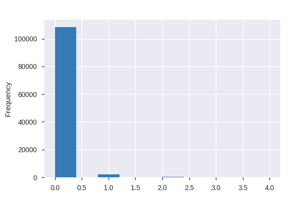

**Common Values**

| Value | Count | Frequency (%) |  |
| --- | --- | --- | --- |
| 0 | 108286 | 98.0% |  |
| 1 | 2042 | 1.8% |  |
| 2 | 183 | 0.2% |  |
| 3 | 13 | 0.0% |  |
| 4 | 3 | 0.0% |  |

**Extreme Values**

Minimum 5 values

| Value | Count | Frequency (%) |  |
| --- | --- | --- | --- |
| 0 | 108286 | 98.0% |  |
| 1 | 2042 | 1.8% |  |
| 2 | 183 | 0.2% |  |
| 3 | 13 | 0.0% |  |
| 4 | 3 | 0.0% |  |

Maximum 5 values

| Value | Count | Frequency (%) |  |
| --- | --- | --- | --- |
| 0 | 108286 | 98.0% |  |
| 1 | 2042 | 1.8% |  |
| 2 | 183 | 0.2% |  |
| 3 | 13 | 0.0% |  |
| 4 | 3 | 0.0% |  |

SMS_received  
Boolean

| Distinct count | 2 |
| --- | --- |
| Unique (%) | 0.0% |
| Missing (%) | 0.0% |
| Missing (n) | 0 |

| Mean | 0.32103 |
| --- | --- |

| 0 | 75045 |
| --- | --- |
| 1 | 35482 |

Toggle details

| Value | Count | Frequency (%) |  |
| --- | --- | --- | --- |
| 0 | 75045 | 67.9% |  |
| 1 | 35482 | 32.1% |  |

No-show  
Categorical

| Distinct count | 2 |
| --- | --- |
| Unique (%) | 0.0% |
| Missing (%) | 0.0% |
| Missing (n) | 0 |

| No | 88208 |
| --- | --- |
| Yes | 22319 |

Toggle details

| Value | Count | Frequency (%) |  |
| --- | --- | --- | --- |
| No | 88208 | 79.8% |  |
| Yes | 22319 | 20.2% |  |

Correlations

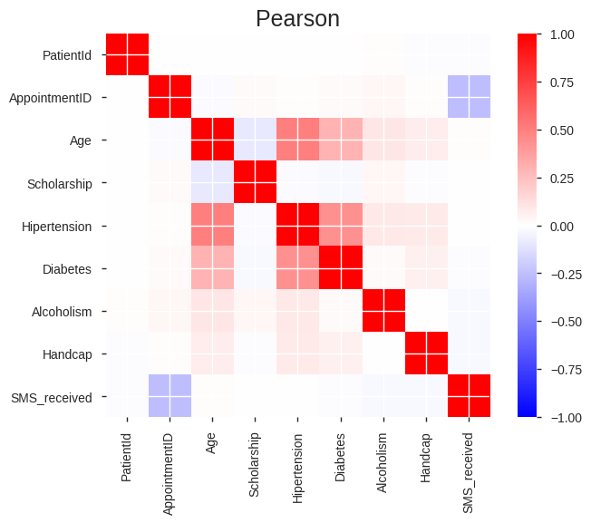

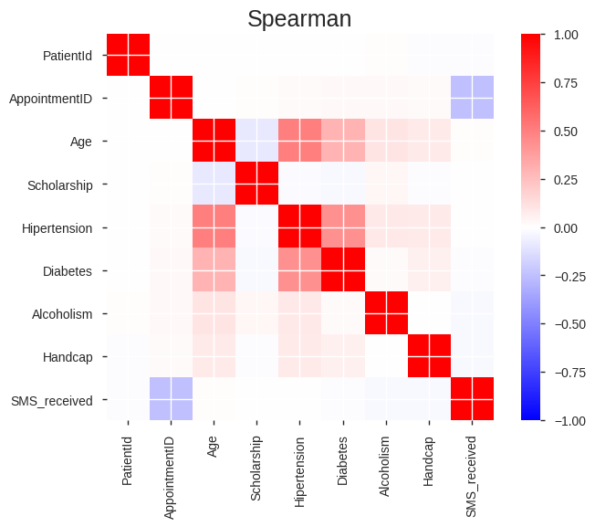

Sample

|  | PatientId | AppointmentID | Gender | ScheduledDay | AppointmentDay | Age | Neighbourhood | Scholarship | Hipertension | Diabetes | Alcoholism | Handcap | SMS_received | No-show |
| --- | --- | --- | --- | --- | --- | --- | --- | --- | --- | --- | --- | --- | --- | --- |
| 0 | 2.987250e+13 | 5642903 | F | 2016-04-29T18:38:08Z | 2016-04-29T00:00:00Z | 62 | JARDIM DA PENHA | 0 | 1 | 0 | 0 | 0 | 0 | No |
| 1 | 5.589978e+14 | 5642503 | M | 2016-04-29T16:08:27Z | 2016-04-29T00:00:00Z | 56 | JARDIM DA PENHA | 0 | 0 | 0 | 0 | 0 | 0 | No |
| 2 | 4.262962e+12 | 5642549 | F | 2016-04-29T16:19:04Z | 2016-04-29T00:00:00Z | 62 | MATA DA PRAIA | 0 | 0 | 0 | 0 | 0 | 0 | No |
| 3 | 8.679512e+11 | 5642828 | F | 2016-04-29T17:29:31Z | 2016-04-29T00:00:00Z | 8 | PONTAL DE CAMBURI | 0 | 0 | 0 | 0 | 0 | 0 | No |
| 4 | 8.841186e+12 | 5642494 | F | 2016-04-29T16:07:23Z | 2016-04-29T00:00:00Z | 56 | JARDIM DA PENHA | 0 | 1 | 1 | 0 | 0 | 0 | No |

```python
#Performing pandas quick analaysis
profile = ProfileReport(df)
profile
```

```python
#Checking The Shape
df.shape
```

```
(110527, 14)
```

```python
#Getting a Brief Summary Of Our Data Set
df.describe()
```

|  | PatientId | AppointmentID | Age | Scholarship | Hipertension | Diabetes | Alcoholism | Handcap | SMS_received |
| --- | --- | --- | --- | --- | --- | --- | --- | --- | --- |
| count | 1.105270e+05 | 1.105270e+05 | 110527.000000 | 110527.000000 | 110527.000000 | 110527.000000 | 110527.000000 | 110527.000000 | 110527.000000 |
| mean | 1.474963e+14 | 5.675305e+06 | 37.088874 | 0.098266 | 0.197246 | 0.071865 | 0.030400 | 0.022248 | 0.321026 |
| std | 2.560949e+14 | 7.129575e+04 | 23.110205 | 0.297675 | 0.397921 | 0.258265 | 0.171686 | 0.161543 | 0.466873 |
| min | 3.921784e+04 | 5.030230e+06 | -1.000000 | 0.000000 | 0.000000 | 0.000000 | 0.000000 | 0.000000 | 0.000000 |
| 25% | 4.172614e+12 | 5.640286e+06 | 18.000000 | 0.000000 | 0.000000 | 0.000000 | 0.000000 | 0.000000 | 0.000000 |
| 50% | 3.173184e+13 | 5.680573e+06 | 37.000000 | 0.000000 | 0.000000 | 0.000000 | 0.000000 | 0.000000 | 0.000000 |
| 75% | 9.439172e+13 | 5.725524e+06 | 55.000000 | 0.000000 | 0.000000 | 0.000000 | 0.000000 | 0.000000 | 1.000000 |
| max | 9.999816e+14 | 5.790484e+06 | 115.000000 | 1.000000 | 1.000000 | 1.000000 | 1.000000 | 4.000000 | 1.000000 |

```python
#Getting More Info (Null & data type of each coloumn)
df.info()
```

```
<class 'pandas.core.frame.DataFrame'>
RangeIndex: 110527 entries, 0 to 110526
Data columns (total 14 columns):
PatientId         110527 non-null float64
AppointmentID     110527 non-null int64
Gender            110527 non-null object
ScheduledDay      110527 non-null object
AppointmentDay    110527 non-null object
Age               110527 non-null int64
Neighbourhood     110527 non-null object
Scholarship       110527 non-null int64
Hipertension      110527 non-null int64
Diabetes          110527 non-null int64
Alcoholism        110527 non-null int64
Handcap           110527 non-null int64
SMS_received      110527 non-null int64
No-show           110527 non-null object
dtypes: float64(1), int64(8), object(5)
memory usage: 11.8+ MB
```

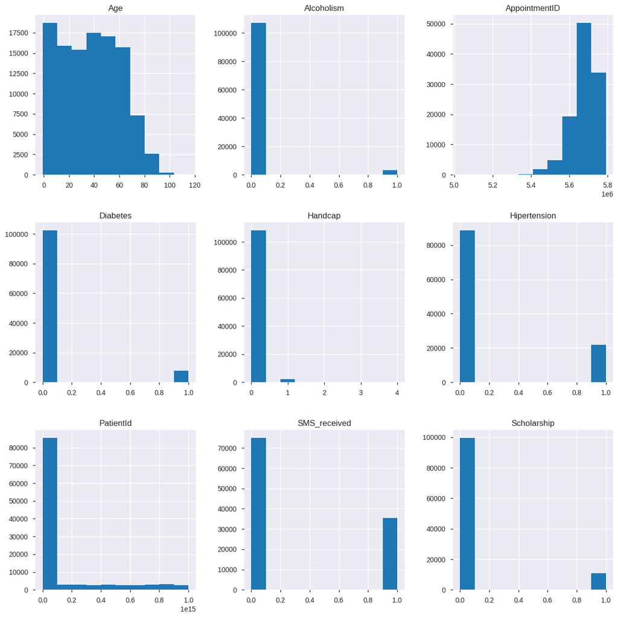

```python
#visualising our data to get a visual overview
df.hist(figsize=(15, 15));
```

> 2- we also notice that the max value for handicap column is 4 which makes no sense since the value should either be 0 as not handicapped or 1 as handicapped (classifier indecator) not an actual value

> 3- patient id , appointment id won't really matter to our data analysis as they are very specific or non relatable or correlatable data or can't cause a differance in the patients ability to show or not

> 4- we also notice that the handcap column need to be renamed from handcap to handicap